# Uvod i Dizajn Sistema Visokih Performansi

Veljko Petrović

2026-01-01

# Servisne informacije

Opšti podaci o predmetu.

## Malo o predavaču

- Veljko Petrović
- Sedim u NTP 330 kancelariji
- Čekamo da se sredi raspored pre nego što uvedemo stalni termin konsultacija.
- Konsultacije mogu i po posebnom dogovoru kada je potrebno
- Možemo da se čujemo i online, naravno.

## Kontaktiranje - elektronska pošta

- Najbolje me je tražiti na `pveljko@uns.ac.rs`
- Vodite računa da neretko dobijam čitav *tsunami* elektronske pošte, možda vašu ne vidim ili ne vidim na vreme.
- Ako ste zabrinuti da vam nisam video poruku, slobodno je šaljite opet.
- Ako želite da dobijete odmah odgovor (makar on bio samo ‘video’) molim stavite reč HITNO u subject poruke.

## Šta je RVP

- U pitanju je prevod—tehnički kalk—engleskog termina ‘High Performance Computing’ čiju ću skraćenicu (HPC) ja koristiti kao ime kursa u budućnosti.
- Opšte govoreći, videćete neobično puno engleskih termina u ovim predavanjima.
- Što?
  - Nekad nema prevoda
  - Nekad prevod odudara zbog naše nenaviknutosti
  - Uvek je neophodno znati engleski termin ako želite da koristite Internet pretragu.

## Literatura

- Dokumentacija, ovi slajdovi, i beleške sa predavanja bi trebali da budu sasvim dovoljni.
- Predavanja su bazirana u velikoj meri na izvrsnoj knjizi “High Performance Computing: Modern System and Practices” čiji su autori T. Sterling, M. Anderson, i M. Brodowicz. Takođe se preporučuje: “Introduction to High Performance Scientific Computing,” Victor Eijkhout koja je dostupna kroz Creative Commons licencu. http://pages.tacc.utexas.edu/~eijkhout/Articles/EijkhoutIntroToHPC.pdf.

## O slajdovima

- Slajdovi su novi za ovu generaciju i predstavljaju proširenu verziju slajdova ranijih godina
- Promenila se i tehnologija slajdova: sada se koristi Quarto izdavački sistem koji generiše web-bazirane `revealjs` prezentacije. Pogledajte ovde: https://pveljko-ftn.github.io/predavanja-HPC/01.html za prvu prezentaciju.

## Kako se polaže?

- Predispitne obaveze nose 70 bodova
- Kako te bodove stičete čućete na vežbama
- Ispit nosi 30 bodova
- Te bodove stičete na klasičnom ispitu koji će gotovo sigurno biti usmen i pokrivaće gradivo koje ste radili na predmetu.

## Infrastruktura

- Budući da je predmet zahtevan, nemamo baš najbolju moguću podršku u laboratorijama fakulteta
- Trebaće vam Linux, idealno najsvežija Fedora ili Ubuntu bilo direktno instaliran, bilo u virtuelnoj mašini.
- Dosta posla će se raditi iz komandne linije.
- Naš primarni jezik je C/C++, mada će biti i malo Python-a i R-a kasnije.
- Sav naš alat će biti Open Source izuzimajući, opciono, CLion IDE.
  - CLion se plaća i to puno, ali kao studenti FTN-a imate pravo na besplatnu JetBrains licencu.
  - Ako ne želite IDE, Visual Studio Code / Codium je sasvim prikladan ili naravno neki drugi editor u kome uživate.
  - Naravno, `neovim` je najbolji. 😁

## Linux?

- Da, Linux.
- Ispostavilo se, avaj, da nijedna godina nije godina Linux-a na desktop-u, ali kao utešna nagrada, svaka godina je godina Linux-a u HPC primenama.
- Upotreba bilo čega drugog nije ni opcija za nas.
- Ako vam rad sa Linux-om nije udoban, krajnje je vreme da se naviknete.

## Komandna linija

- Resursima HPC sistema se pristupa manje-više isključivo iz komandne linije i dosta alata se može, u stvari, samo razumeti u kontekstu komandne linije i nikako drugačije.
- Treba će vam razumevanje osnovnih komandi i sistemskih promenljivih da bi razumeli kako alati koje mi koristimo rade.

## C/C++

- Nemamo izbora.
- Ovo, baš ovo, je mesto gde C i C++ briljiraju.
- Ima modernih jezika koji su interesantni i obećavaju da će eventualno smaknuti u ovoj oblasti primenu C i C++, ali još nisu u potpunosti zavladali
  - Rust je naročito bitan jezik
  - Go je takođe bitan kada se govori o performantnim sistemima
- C/C++ je tehnički… pipav termin. Ono što ja ovde mislim jeste C i, gde možemo, moderan C++.
- Budite srećni, mogli smo da koristimo FORTRAN.

## Python i R

- Biće malo ova dva jezika kada budemo pričali o vizuelizaciji.
- HPC rad je retko rad sam za sebe—tipično rešavamo nekakav problem.
  - Stoga, heterogenost jezika je česta.
- Neretko postoji prototip u nečemu udobnom kao što je Python, a vaš posao je da uzmete to i učinite ga mnogo bržim.
- Naravno, Python je apsolutno ključan kada je u pitanju mašinsko učenje.

# Problemi Performansi

Brzo o bzini i optimizaciji.

## Šta su performanse

- Imamo dve moguće definicije:
  - Teoretske performanse.
  - Praktične performanse.
- Teoretske performanse su apsolutni maksimum koji neki hardverski sistem može da izvuče i meri se u broju nekakvih operacija u sekundi. Najčešće, jedinica je FLOPS—FLoating point OPeration per Second.
- Računari kakve vi, realistično, imate imaju performanse koje se mere u desetinama gigaFLOPSa, ne računajući GPU.
- Najbrži računar? LineShine. 2187.40 petaflopsa. 13789440 jezgara. Čudo šta 42.22MW može da uradi.

## Šta su performanse?

- To je lepo, ali nama ne treba računar da troši struju i zvuči impresivno.
- Nama treba rešenje, i to dovodi do praktičnih performansi.
- Praktične performanse su, efektivno, koliko vremena treba da se dođe do rešenja.
- Mnogo su realističnije (pošto nas baš to zanima) ali dobiti ih je jako jako teško.
- Tipično se procenjuju na osnovu kalibracionog programa—Benchmark-a.

## Kako programer zamišlja računar?

- Moj program ima nekakve podatke i sam kod.
- I jedno i drugo živi u memoriji.
- Kod se sastoji od atomskih operacija, instrukcija koje traju neku jedinicu vremena $t_i$.
- Procesor izvršava moje instrukcije, jednu po jednu.
- Ako hoću brži program, opcije su mi:
  - Manje instrukcija.
  - Kraće $t_i$.

## Oh, sweet child of summer…

- …svi vi, znate, nadam se, da ovo nije tačno.
- Ali možda ne znate *koliko* nije tačno.
- Ipak, iako nije tačno ovo nije potpuno beskorisno.
- Minimizacija broja instrukcija je, generalno govoreći, dobar način da se program ubrza.
- Možete misliti o ovome kao o kontroli vremenske kompleksnosti algoritma.
- To je dobra ideja, ali ne svrha ovog kursa.

## Dobro, šta ne valja sa ovom pričom?

- Vaš procesor ima u sebi, efektivno, više procesora.
- Ali svaki od tih procesora izvršava više stvari istovremeno.
- Takođe, ta istovremenost je kompleksna zahvaljujući pipelining-u.
- Takođe takođe, mehanizmi u računaru operišu na kompletno različitim vremenskim skalama.
- Takođe takođe…

## Ovo je komplikovanije nego što izgleda

- Računar se jako trudi da vam predstavi sliku da je samo instancirana Fon Nojmanova arhitektura i da je memorija lako i proizvoljno adresabilna.
- Lakše je tako programirati i većinu vremena želite tu iluziju, ali ne i kada hoćete da iscedite svaki poslednji dram performansi iz sistema.

## Dijagram procesora

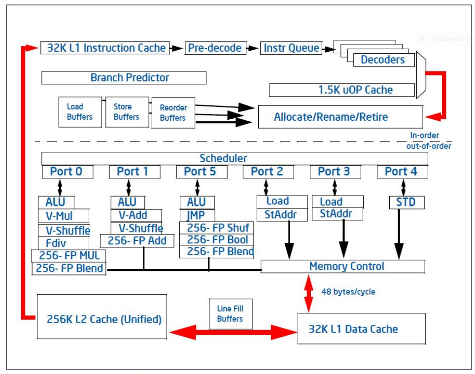

## Šta su glavne komplikacije na jednom računaru?

- Ne zaboravite, ovde još pričamo o prostom računaru koji vam stoji na radnom stolu.
- Prvo, ima više jezgara.
- Drugo, instrukcije mogu da traju različiti broj ciklusa.
- Dalje ima paralelizam na nivou instrukcija (eng. Instruction Level Paralelism)
- Memorija ima striktnu hijerarhiju

## ILP

- Nezavisne instrukcije mogu da krenu da se izvršavaju u isto vreme, koristeći paralelne strukture u samom silikonu.
- Zahvaljujući sekvenci izvršavanja, više funkcija može da ide jedno za drugim u protočnom režimu (eng. “pipelining” )
- Da ne bi bilo praznog hoda, procesor izvršava grane u vašem kodu pre nego što se zna u koju će se ući. Ako je pogodio kako treba, odlično, ako ne rezultat se baca i program se vraća u prethodno stanje.
- Da bi pipelining radio što bolje, instrukcije za koje je to moguće će biti izvršene u najoptimalnijem redosledu ne vašem redosledu.
- Podaci se dostavljaju iz nivoa memorije u nivo memorije spekulativno, tj. ako se misli da će možda trebati.

## Dijagram pipeline pristupa

```
graph LR
A[Instruction fetch] --> B[Dekodiranje] --> C[Data fetch] --> D[Poravnavanje eksponenata] --> E[Dodavanje mantisa] --> F[Normalizacija] --> G[Smeštanje rezultata]
```

## Pipeline ubrzanje

- $n$ — broj proračuna koje hoćemo
- $l$ — broj koraka u procesnom toku
- $\tau$ — vreme za jedan ciklus sistemskog sata
- $t(n)$ — vreme za n operacija
- $s$ — vreme neophodno da se namesti da pipelining radi

## Brzina serijskog izvršavanja

$$t(n) = n \cdot l \cdot \tau$$

## Brzina ILP izvršavanja

$$t(n) = (s + l + n - 1) \cdot \tau$$

## Hijerarhija memorije

| Tip memorije | Red veličine | Brzina učitavanja |
| --- | --- | --- |
| Registar | 128 bajtova | Koliko i procesor |
| L1 Keš | ~32KiB | Pola procesora |
| L2 Keš | ~256KiB | Oko šestina procesora |
| L3 Keš | ~32MiB | Oko $\frac{1}{12}$ procesora |
| Glavna memorija | ~32GiB | 100 ciklusa sa oko 5% protoka |
| SSD disk | ~2TiB | Jako dugo |
| HDD disk | ~8TiB | Večnost. |

## Keš

- Nikad nema dovoljno.
- U praksi, automatski mehanizmi pokušavaju da u kešu drže podatke koje nama trebaju.
- Ako, kada program zatraži podatak, on stoji u kešu odlično. Imamo ubrzanje.
- Ako ne, imamo omašaj, ond. “cache miss.”

## Katalog omašaja

- Neizbežan
  - Kada prvi put tražimo podatke.
- Kapacitetski
  - Kada nema više mesta.
- Konflikt
  - Kada mapiramo (keš menja memoriju, tj. lokacije u kešu su ubrzane memorijske lokacije sa tačke gledišta adresiranja), mapirali smo dve stvari na isto mesto.
- Invalidacija
  - Više jezgara se posvađalo oko toga šta je najsvežija verzija nekog podatka.

## Keš blok

- Instrukcije ne mogu da direktno adresiraju keš
- I dalje misle da pričaju sa glavnom memorijom
- Ovo je česta apstrakcija odgovorna i za, npr. memory-mapped I/O
- Iza kulisa, mikrokontroler procesora uzima podatke iz memorije i smešta ih u keš u jedinicama fiksne veličine (blokovima).
- Tipično, 128 bajtova. To znači da dobijamo ceo taj komad memorije hteli mi to ili ne.
- Zatim se beleži koji deo memorije je mapiran na koji deo keša i, kada ponestane prostora, menja se najdavnije korišćeni deo po LRU principu.
  - Ovo je laž. Više o tome kasnije.

## Koja je praktična primena znanja o keš blokovima?

- Pakovanje podataka.
- Ako prolazimo kroz niz element po element, kada učitamo prvi element, uz njega dolazi $N$ sledećih džabe.
- Ako procesiramo svaki element, onda to je to.
- Ali šta ako je ovo niz tačaka u 3D prostoru a nas samo zanima $X$ vrednost.
- Imamo jako puno bačenih učitavanja.
- Ako znamo kako će neki podaci biti procesirani, isplati se da se upakuju tako da podaci koji se zajedno koriste budu blizu.

## Array Stride

- Recimo da hoćemo da saberemo dva niza kompleksnih brojeva.
- To znači (ako koristimo double preciznost) da nam treba 16 bajtova po broju.
- Keš linija je, recimo, 128.
- To znači da bi trebalo da je brže da se brojevi sa sabiranje prepletu u jedan niz.
  - Re(A0)
  - Im(A0)
  - Re(B0)
  - Im(B0)
  - Re(A1)
  - …

## Address alignment

- Lukaviji možda mogu da primete da ja mogu da adresiram bilo koju adresu u glavnoj memoriji na bajt nivou, čak i ako radim na nivou reči.
- Da li to znači da nekako, magično, ima poravnanje između keša i memorije?
- Ne. Multi-bajt vrednost može vrlo lako da bude u dva keš bloka.
- Ovo je spektakularno loše po performanse.
- Ponekad, kompajler je dovoljno pametan da to otkloni.
- A ako nije?

## Address alignment

```c
#include <stdio.h>
#include <stdlib.h>
```

## Address alignment

```c
#include <stdio.h>
#include <stdlib.h>

int main(){
  double* a = NULL;
  a = malloc(1024 * 8);
  printf("%p\n", a);
  free(a); //da li je ovo poravnano?
}
```

## Address alignment

```c
#include <stdio.h>
#include <stdlib.h>

int main(){
    double* a = NULL;
    double* aligned_a = NULL;
    a = malloc(1024 * 8 + 8);
    printf("%p\n", a);
    aligned_a = a;
    if((size_t)a % 8 != 0){
        aligned_a = (double*)(( ((size_t)a >> 3) << 3));
    }
    printf("%p\n", aligned_a);
    free(a);
}
```

## Address alignment

```c
#include <stdio.h>
#include <stdlib.h>

int main(){
    double* a = NULL;
    double* aligned_a = NULL;
    size_t numeric_a = 0;
    a = malloc(1024 * 8 + 8);
    printf("%p\n", a);
    aligned_a = a;
    numeric_a = (size_t)a;
    if((numeric_a) % 8 != 0){
        numeric_a = ((numeric_a + 8) >> 3) << 3;
        aligned_a = (double*)numeric_a;
    }
    printf("%p\n", aligned_a);
    free(a);
}
```

## Address alignment

```c
#include <stdio.h>
#include <stdlib.h>

int main(){
    double* a = NULL;
    double* aligned_a = NULL;
    size_t numeric_a = 0;
    int n = 3; //poravnavanje na 2^n bitova.
    a = malloc(1024 * 8 + (1 << n));
    printf("%p\n", a);
    aligned_a = a;
    numeric_a = (size_t)a;
    if((numeric_a) % (1 << n) != 0){
        numeric_a = ((numeric_a + (1 << n)) >> n) << n;
        aligned_a = (double*)numeric_a;
    }
    printf("%p\n", aligned_a);
    free(a);
}
```

## Rezultat eksperimenta

- Na GCC 13.2.1, ovo je beskorisno. Već dobijam poravnanu memoriju.
- Jako puno zavisi od kompajlera, i često morate kod da tetošite predprocesorskim direktivama da dobijete ono što želite.

## Malo sam lagao o kešu…

- Rekao sam ranije da se beleži region memorije i lokacija u kešu
- To… baš i nije tačno.
- To bi zahtevalo tkzv. asocijativan keš. Ovi su spori.
- Ono što se koristi u praksi je $k$-struki asocijativan keš.
- To znači da postoji transformaciona funkcija koja mapira lokaciju u memorji na lokaciju u kešu na više mogućih načina. Tipično od 2 do 8.
- Onda, u slučaju konflikta u mapiranju, koristi se jedna od dodatnih lokacija oslobođena po LRU principu.

## Šta je sve ovo trebalo da me nauči?

- Osim malo o arhitekturi računara ima još i ovo:
- Kako se nešto implementira interaguje jako komplikovano sa hardverom procesora i računara uopšte da proizvede performanse.
- Stoga, programiranje performantnog koda može biti jako izazovno.
- A sve ovo je na samo jednom računaru…

# Uvod u koncept modernog HPC

Šta kada procesor jednostavno nije dovoljno brz…?

## Paralelizam

- Prethodna sekcija je pokazala da su performanse teške, ali je sva bila opsednuta time da se iz jednog procesora izvuče maksimum.
- Budući da se naš kod, na kraju dana, izvršava na nekom procesoru, negde, to nije loša ideja i uvek će biti relevantno, ali šta kada 100% nekog procesora nije dovoljno brzo?
- Postoje praktične granice gigahercaži koju možemo da dobijemo iz čipa
  - Bakar
  - Brzina svetlosti

## Paralelizam

- Zbog ovoga superračunari danas nisu (i verovatno nikad više neće biti) jedan jako moćan procesor.
- Ono što čini superračunar super jeste broj procesorskih elemenata.
- Da bi se broj procesorskih elemenata iskoristio kako treba, potrebno je pisati kod koji je paralelan, tj. izvršava više stvari istovremeno.
- Ovo nije paralelizam na nivou instrukcije, koliko je paralelizam na nivou algoritma.
- Priroda algoritma dramatično utiče na to koliko je lako odn. teško izvršiti paralelizaciju.

## Šta je naš posao?

- Da dobijemo odgovor jako jako brzo.
- Da, ali kako?
- Napadamo problem sa dve strane:
  - Arhitektura
  - Algoritam
- Dakle, treba da napravimo mašinu koja ima jako efektan dijapazon procesora koji brzo komuniciraju i imaju šta im treba da ostvare blizu svom teoretskom maksimumu.
- Sa druge strane treba da upravljamo tom mašinom i podelimo algoritme na takav način da se adekvatni delovi algoritma izvršavaju na pravom mestu radi brzine.

## Anatomija jednog superračunara

- Superračunar tipično ima neki broj čvorova.
- Čvor se može zamisliti kao jedan računar.
- Trenutno drugi najbrži računar na svetu je El Capitan (Najbrži je LineShine, ali je njegova arhitektura donekle atipična).
- Taj računar je 11 136 čvorova, gde je svaki odvojen računar koji ima 4 MI300A APU-a

## MI300A

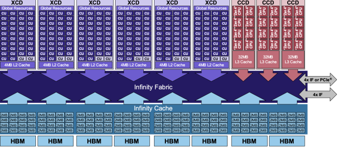

## MI300A

- Ovaj APU je kombinacija 6 “grafičkih kartica” i 3 “procesora”
- Svaka od XCD pseudo-GPU jedinica ima 38 komputacionih jedinica
- Svaki APU ima 24 Zen4 x86_64 jezgara sa AVX512 i BFloat16 ekstenzijama

## Mnogo paralelizama

- Ovde ima jako puno stvari koje podržavaju paralelizam
- Izazov jeste napraviti kod koji ima odgovarajući posao za svaki paralelizam koji hardver nudi
- Neke stvari su taman za rad na jednom jezgru ili jednom procesoru
- A neki poslovi se najbolje dele između individualnih čvorova gde je komunikacija između njih izuzetno retka.
- Različite tehnologije su dobre za različite nivoe paralelizma. Gledano iz ptičije perspektive

## Mnogo paralelizama

| Hardverski nivo paralelizma | Tehnologija |
| --- | --- |
| Unutar jednog procesora | pThreads / OpenMP |
| Između čvorova | MPI |
| Na GPU uređajima | OpenACC / CUDA / ROCm |

## Skaliranje

- Skaliranje je kako ukupne ostvarne performanse zavise od veličine sistema.
- Tj. ako povećamo računar dva puta koliko dodatnih performansi dobijemo od toga?
- Idealno dva, da, ali…
- Skaliranje ima dva tipa
  - Slabo
    - Uniformni rast veličine sistema, memorije i problema.
  - Jako
    - Veličina problema ostaje ista, skalira se veličina sistema za povećanje brzine.

## Šta smeta skaliranju

- **O**verhead
  - Sav taj kod koji deli podatke i vodi računa ko radi kada šta i integriše rezultate itd. itd. itd. oduzima neko vreme i neke resurse da se izvrši.
- **W**aiting
  - Čim ima više niti izvršavanja može doći do problema nadmetanja (contention) oko deljenih resursa. Ovo se rešava čekanjem.

# Kratka istorija

Kako smo stigli ovde?

## Mehaničko računanje

- Želja za mašinom koja računa umesto nas, ili barem proces čini lakšim je verovatno samo par minuta mlađa od samog koncepta računanja.
- Rano računanje je, u stvari, bilo samo po sebi fundamentalno vezano za nekakvo pomoćno ustrojstvo.
- Drevni Rimljani su imali brojeve koji su bili prilično teški za mehaničku manipulaciju
- Mislim, koliko je LXVII puta XI? A da ne prebacite prvo u arapske brojeve?
- Rimljani su imali metod koji je uključivao pažljivo napravljenu tablicu i kamenčiće.
- Deminutivska množina reči za ’kamen’ na latinskom je ’calculi’
- Odatle kalkulator, kalkulisanje, itd. itd.

## Mehaničko računanje

- Ovo je nastalo, toliko da su ljudi koji su radili sa novcem (te mnogo računali) u kasnosrednjevekovnoj Italiji uvek imali pri ruci klupu sa ucrtanom šemom za račun.
- Termin za klupa je bio ’banca’
- Kasnije su prešli na novi, divni metod za računanje koji ne zahteva klupu no upotrebljava čudne strane cifre. Taj metod su zvali po iskvarenom imenu osobe koju su držali za njegovog kreatora, (Muhammad ibn Musa al-Khwarizmi), ’algorismus’
- Mušterije nisu verovale ovakom algorismičnom bankarstvu i hteli su klupe nazad. Naročito omrznuta je bio potpuno novi simbol—nula. Toliko je bila omrznuta da je arapsko ime za nju—al sifr—ušlo u skoro sve evropske jezike.

## Mehaničko računanje

- Ne možemo, očigledno da se oslobodimo mehaničkih računala.
- Prva mehanička računala su bila fundamentalno samo računaljke.

## Abakus

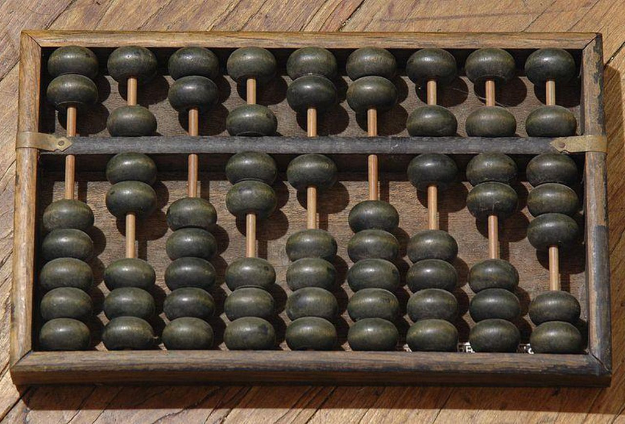

## Logaritmar

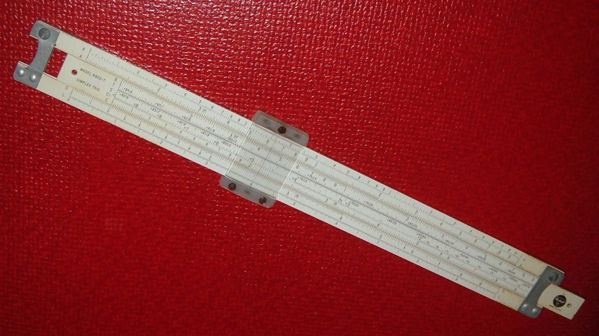

## Paskalina

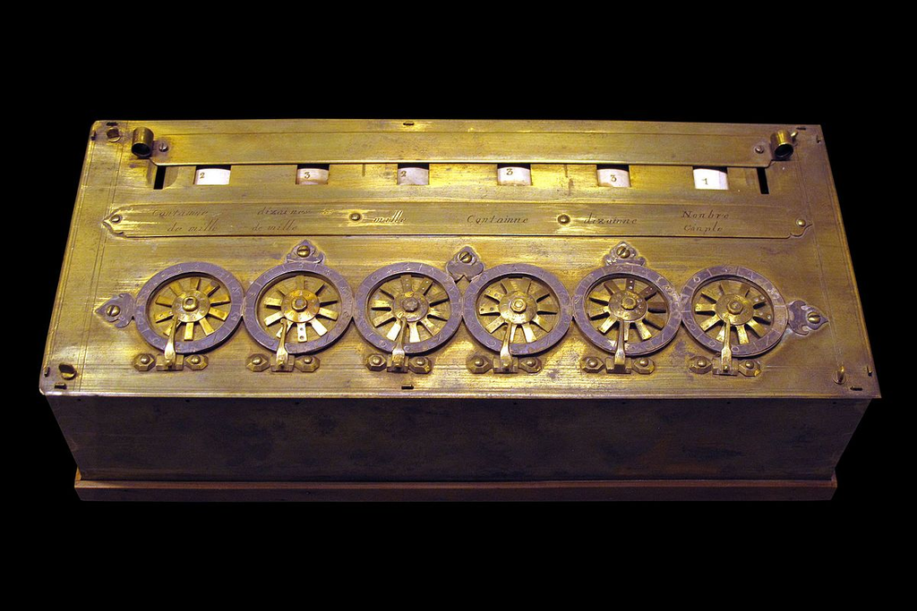

## Curta

[figure not shown]

## Da li su ovo računari?

- Nikako.
- Ovo ne radi posao računara.
- Ako išta simulira ponašanje aritmetičko-logičke jedinice računara, ništa više.

## Antikiteranski mehanizam

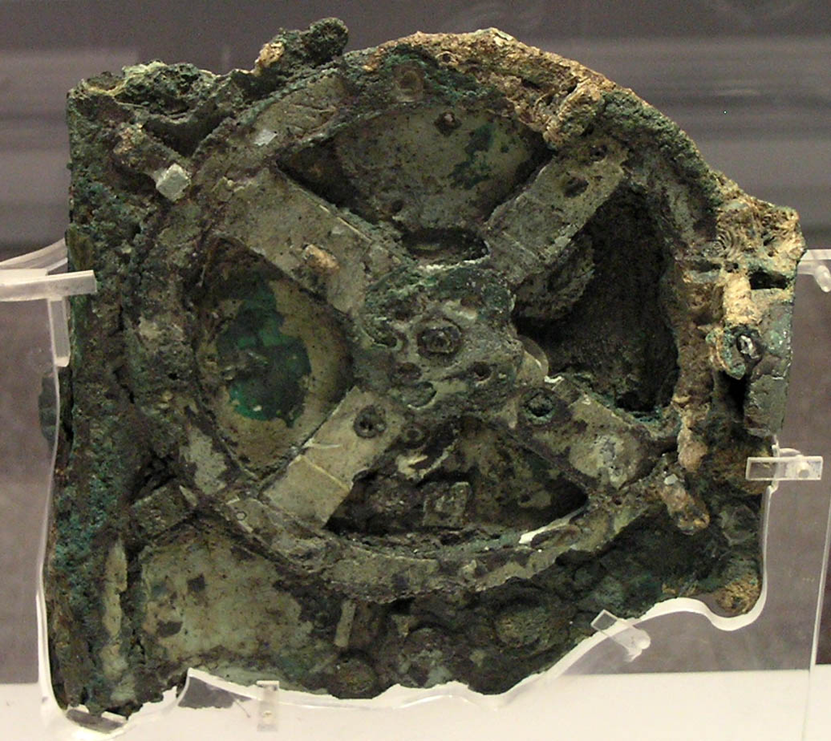

## Dijagram

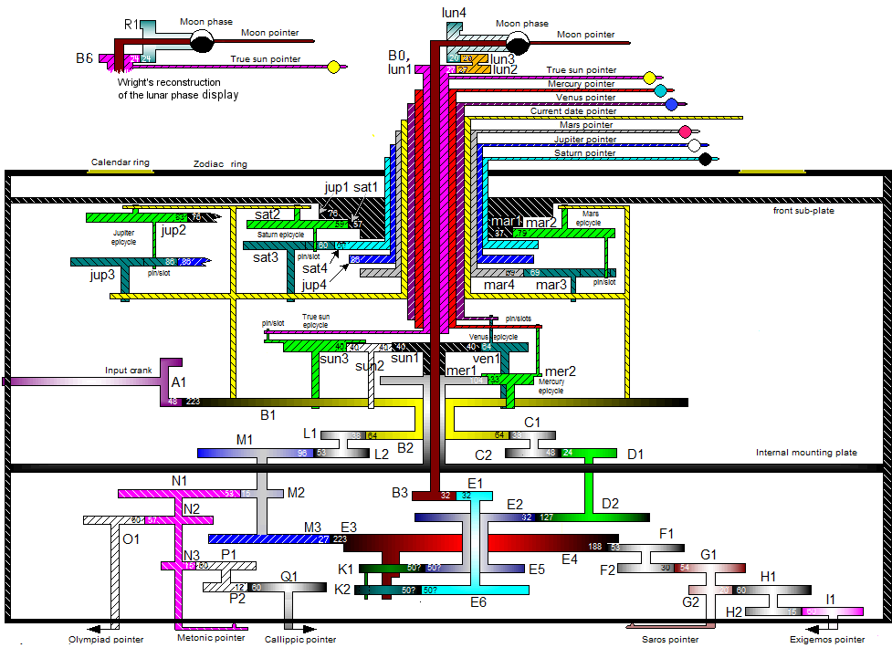

## Analogni računar

- Možete misliti o analognom računaru kao o kompleksnoj fizičkoj inkarnaciji matematičke funkcije
- Recimo, neka kombinacija zupčanika ili električnih kola ili spojenih sudova odgovara, recimo, nekoj klasi diferencijalne jednačine.
- Možemo da menjamo parametre i koeficijente
- *Ne možemo* da programiramo takav računar, tj. on ne poseduje osobinu *univerzalne izračunljivosti*

## The Difference Engine

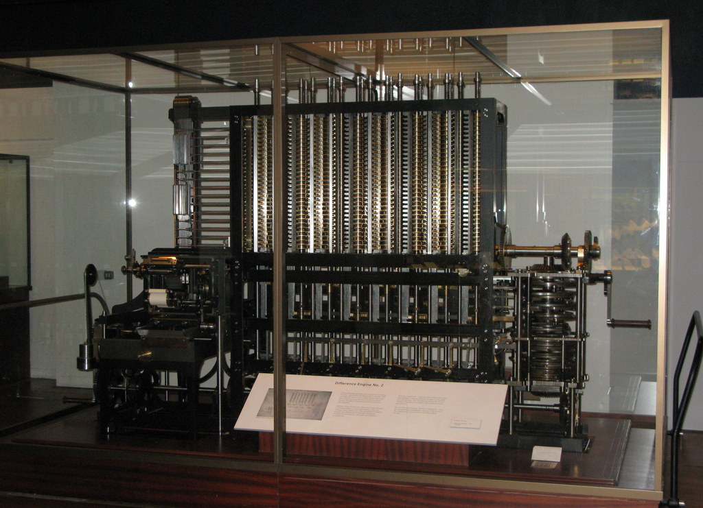

## Računar?

- Ne *sasvim*
- Ovo je inkarnacija *ogromne* porodice funkcija.
- Ali i dalje nije univerzalan u Čerč-Tjuringovom smislu.
- Ne može da se programira u istinskom smislu te reči.

## The Analytic Engine

[figure not shown]

## Prvi pravi računar…

- …ali samo na papiru.
- Memorija, programi, opšta namena…
- Ceo računarski sistem kakvim ga mi razumemo
- Nikad nije bio napravljen
- Moderne studije pokazuju da bi apslutno radio, samo što bi investicija bila neverovatna.

## Da se uozbiljimo

- Šta je sa istorijom elektronskih super-računara?
- Tradicionalno ovo se deli u epohe gde svaku karakteriše dominacija određenih tehnologija.
- Te epohe su kao, npr. ‘generacije’ u koju se dele igračke konzole: konvencionalne i donekle ad hoc

## Epoha 1 - Era elektromehanike

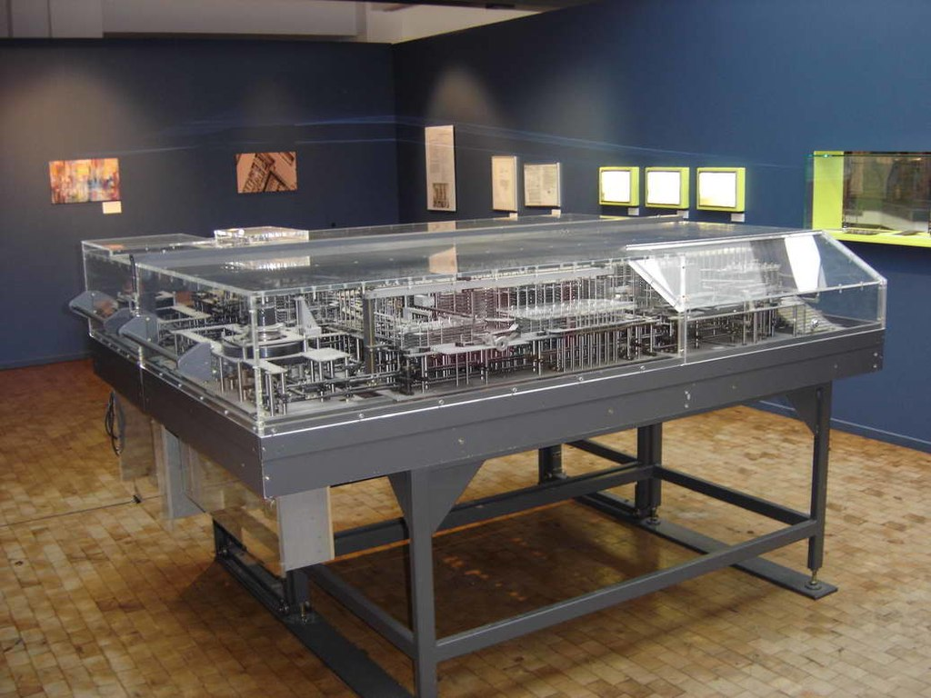

Zuse 1

## Epoha 1 - Era elektromehanike

[figure not shown]

Harvard Mk 1

## Epoha 1 - Era elektromehanike

- Brzine od čak jedne instrukcije u sekundi!
- Bušene kartice za I/O
- Još nema programskih jezika kao takvih
- Čerč i Tjuring postavljaju teoretske osnove računara

## Epoha 2 - Fon Nojmanova Arhitektura i Vakumske Cevi

- ENIAC
- EDSAC (1949)
- Colossus
- Mančesterska Beba
- IBM 704 (Rana veštačka inteligencija)
- UNIVAC (1951)

## Epoha 2 - Fon Nojmanova Arhitektura i Vakumske Cevi

- Vrhunske mašine ere postižu do 10 KIPS
- 4KB memorije
- U ranom dobu koriste se živina kola za memoriju
- Kasnije magnetna jezgra
  - Ovo je ostavilo traga do danas—ako vam je ikada pukao program u Linux-u i ostavio ’core dump,’ sada znate odakle ime.
- U ovom periodu:
  - Fon Nojman postavlja osnove moderne arhitekture računara.
  - Klod Šanon postavlja osnove informatike.

## Epoha 3 — Paralelizam na nivou instrukcije i uspon tranzistora

- Era počinje sa TX-0 računarom i vodi preko DEC PDP-1 i IBM 7090 do vrhunca treće epohe
- CDC 6600 (1965)

## Epoha 3 — Paralelizam na nivou instrukcije i uspon tranzistora

[figure not shown]

CDC 6600

## Epoha 3 — Paralelizam na nivou instrukcije i uspon tranzistora

- CDC6600 je imao
  - 1 MFLOPS!
  - 10 MHz takt!
  - 10 logičkih jedinica!
  - Prvi ILP!
  - Jedan od prvih uređaja koji se zvao „superkompjuter“

## Epoha 4—Vektorski procesori i integrisana kola

- Računar koji je obeležio ovu epohu je legendarni Krej-1 (1976)
  - Sasvim moguće *najlepši* računar svih vremena
- Karakteriše ga izuzetno dugačak pipeline.
- Pošto je ovaj pristup doneo tolike dividende prošli put u ovoj epohi je odguran onoliko daleko koliko može da ide.

## Cray-1

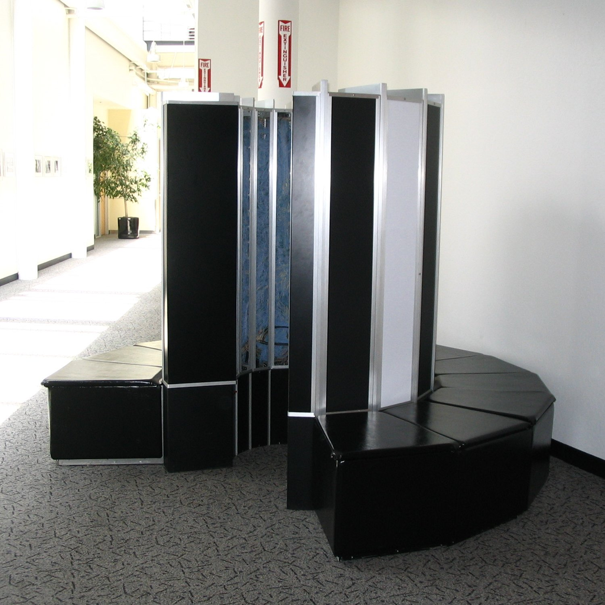

## Epoha 4—Vektorski procesori i integrisana kola

- Krej-1 je mogao
  - 80 MHz!
  - 160 MFLOPS!
  - 8.39 MB memorije!
  - 303 MB diska!

## Epoha 5 — SIMD i spor uspon mikroprocesora

- SIMD je jedna od fundamentalnih HPC arhitektura po Flinovoj taksonomiji (vidi kasnije)
- Podelimo podatke na blokove, a onda radimo istu stvar svakom bloku podataka.
- SIMD — Single Instruction Multiple Data
- Problem sa SIMD-om jeste što su algoritmi bili fantastični za neke stvari i potpuno beskorisni za sve ostalo.
- SIMD i dalje živi—postoji način na koji je svaki GPU u stvari široka SIMD implementacija.
- NEC SX-2
- Prvi računar da probije GFLOPS barijeru

## Epoha 6 — Mnogo Procesora

- Touchstone Paragon (1994)
- IBM SP-2
- Thinking Machines Corporation CM-5 (1992)
- Prvi moderni superkompjuteri
- Prosleđivanje poruka i odvojena memorija, po prvi put.
- Takođe, prvi put se pojavio potrošački klaster (commodity cluster)
- UC Berkley NOW
- Beowulf
- PC + Linux + Ethernet + MPI = Supercomputing For Everyone

## Epoha 7?

- Mi smo ovde.
- I dalje su dominantne tehnologije iz šeste epohe ali uz dodatak ekstremne heterogenosti.
- U jednom čvoru imamo i SIMD i shared-memory i message-passing.
- Moglo bi se reći da ovo predstavlja odrastanje HPCa.

## Dalje?

- Ovo su predviđanja iz 2018. Kako su opstala?
- Masivne online mreže.
  - Ovo baš i nije pogodak
  - Latency masovno distribuiranih sistema je jako težak za kontrolu
- 3D čipovi i sintetički dijamant
  - Ovo još nije sa nama, ali istraživanja napreduju
- Neuroprocesori i domain specific arhitekture
  - Ne zovemo ih “neuroprocesori” nego GPU/NPU/TPU, ali ovo je 100% pogodak
- Kvantni računari
  - Kvantno računarstvo je stalno u vestima, ali nije još proizvelo opipljiv rezultat
  - Kvantno računarstvo je fuzija računarskih nauka: već godinama je samo godinu dana daleko

# Arhitektura superračunara

Pregled mogućih rešenja

## Faktori performanse HPC sistema

- Brzina komponenata
  - Koliko se brzo stvari dešavaju na individualnoj komponenti
- Paralelizam komponenata
  - Koliko stvari se izvršava jednovremeno
  - Koliko stvari se efektno paralelizuje
- Efikasnost komponenata
  - Koji procenat vremena je sistem sposoban da radi

## Faktori performanse HPC sistema

- $P$ — performanse sistema kao apstrakcija
- $e$ — efikasnost sistema
- $S$ — faktor skaliranja
- $a$ — funkcija dostupnosti čiji je parametar $R$ — pouzdanost
- $\mu$ — stopa izvršavanja instrukcija kao funkcija čiji je parametar $E$ — snaga

## Faktori performanse HPC sistema

$$P = e \cdot S \cdot a(R) \cdot \mu(E)$$

## O pouzdanosti

- Sporiji algoritmi mogu da priušte da budu provereni i sigurno tačni
- Ali ako hoćemo brzinu greške su neminovne
- Sistemi su jednostavno previše komplikovani

## Citat

**“Što više znam o kompjuterima sve sam više iznenađen kada rade”**

(*Nepoznati FTN student, Hol fakulteta, 2008.*)

## O pouzdanosti

- Ovaj uvid važi još više za superračunare
- Svi ti delovi, sve te komponente
- Zaista je ponekad iznenađenje kada stvari prorade

## Metode pouzdanosti

- Greške nisu kraj sveta
- Pomislite na TCP nasuprot UDP
- Metod koji se koristi najčešće je checkpoint/restart
- Što da ne? Sve što izgubimo je vreme.
- Ako je vreme koje gubimo na povremeni restart manje od vremena koje bi gubili na sporiji algoritam—pobeda!

## Flinova taskonomija

- Postoje mnogi načini da se opiše arhitektura paralelnih sistema i mnogi načini da se takvi sistemi projektuju.
- Da bi mogli da pričamo bez previše mahanja rukama i objašnjavanja dobro je da imamo nekakve zajedničke termine
- Primer takvih zajedničkih termina jeste Flinova taksonomija, sistem denotiranja različitih arhitektura koji je napravio Majkl Flin 70-tih kodina prošlog veka.

## Faktori Flinove taksonomije

- Flinova taksonomija ima dve dimenzije po kojima varira—podaci i instrukcije, označene u sistemu kao D i I.
- I D i I dimenzije mogu da variraju između dve vrednosti: S (single) i M (multiple) po tome da li se u jednom trenutku u sistemu izvršava operacija nad više tokova podataka ili se izvršava više niti kontrole
- Kombinatorika nam, onda, daje ‘ćoškove’ faznog prostora HPC arhitekture:
  - SISD
  - SIMD
  - MIMD
  - MISD

## SISD

- Najklasičnija Fon Nojmanova arhitektura
- Jedna stvar u jednom trenutku
- Ništa danas ne radi ovako, praktično
- No, i dalje je koristan mentalni model pošto vaša userland aplikacija gotovo sigurno radi ovako.

## SIMD

- Uvek se radi ista stvar
- Ali se istovremeno radi na velikom skupu podataka
- Da bi to razumeli, hajde da razmišljamo o idealizovanoj grafičkoj kartici koja izvršava Fongov model senčenja

## SIMD - Fongov model senčenja

$$I_p = k_{a}i_{a} + \sum_{m \in svetla}(k_{d}(\hat{L}_m\cdot\hat{N})i_{m,d} + k_{s}(\hat{R}_m \cdot \hat{V})^{\alpha}i_{m,s})$$

## SIMD - Fongov model senčenja

```
attribute vec3 position;
attribute vec3 normal;
uniform mat4 projection, modelview, normalMat;
varying vec3 normalInterp;
varying vec3 vertPos;

void main(){
  vec4 vertPos4 = modelview * vec4(position, 1.0);
  vertPos = vec3(vertPost4) / vertPos4.w;
  normalInterp = vec3(normalMat * vec4(normal, 0.0));
  gl_Position = projection * vertPos4;
}

precision mediump float;
varying vec3 normalInterp;
varying vec3 vertPos;
uniform float Ka;
uniform float Kd;
uniform float Ks;
uniform float bljestavost;

uniform vec3 ambient;
uniform vec3 diffuse;
uniform vec3 specular;
uniform vec3 lightPos;
//Ovo je verzija sa jednim svetlom

void main(){
  vec3 N = normalize(normalInterp);
  vec3 L = normalize(lightPos - vertPos);

  float lam = max(dot(N, L), 0.0);
  //lam je sada Lambertova vrednost

  float spec = 0.0;
  if(lam > 0){
    vec3 R = reflect(-L, N);
    vec3 V = normalize(-vertPos);
    specUgao = max(dot(R,V), 0.0);
    spec = pow(specUgao, bljestavost);
  }
  gl_FragColor = vec4(Ka * ambient + Kd*lam*difuse + Ks*spec*specular, 1.0);
}
```

## Fongovo senčenje

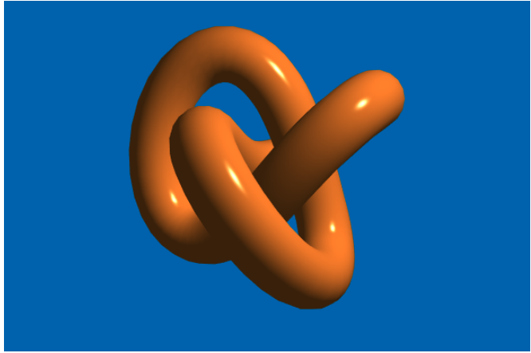

## SPMD

- U praksi SIMD se retko koristi van instrukcija procesora.
- Na drugim mestima, nije paralelizam baš u instrukcijama
- Ali jeste slučaj da imamo jedan program a više tokova podataka.
- Tako da je moderan GPU striktno govoreći primer SPMD arhitekture.
- No, sa druge strane, SPMD je samo praktičnija inkarnacija SIMD ideje.
- Ne treba se previše držati Flinovih apstrakcija. One su divne da nam opišu “ćoškove” prostora u kome obitavamo, ali kretanje po tom prostoru dozvoljava dosta varijacije.
- Moderan **heterogen** sistem je takav da ima zapanjujuće mnogo gradacije između stepena deljene memorije, nivoa paralelizma, itd.

## Heterogen sistem?

- Koristimo taj termin relativno često
- Programiranje u heterogenim sistemima će biti naš glavni izazov
- Pa šta je heterogen sistem?
- Neformalna definicija: Sistem koji meša razne delove Flinove taksonomije u svojim različitim delovima: hibrid raznih arhitektura i pristupa vođen samo željom za najviše performansi.
- Heterogeni sistemi zvuče vrlo novo i uzbudljivo ali, istina je da su oni već duže vremena sa nama i da vi verovatno imate jedan.
- Lični računari su uvek bili heterogeni, a nikad više nego danas gde je razlika između superračunara i nekog igračkog računara uglavno stvar razmere ne prirode.

## SIMD nizovi

- SIMD niz (SIMD Array) je tehnika izrade superračunara koja je svoj vrhunac doživela u 80-tim i 90-tim godinama prošlog veka.
- Ideja je da se računar sastoji od jako mnogo prostih procesorskih elemenata kojima upravlja kontroler sekvence koji se stara da rade istu stvar u isto vreme
- Svaki takav element radi, onda, nad svojim komadom memorije uz minimalno povremeno komuniciranje sa memorijom drugih komada memorije.
- Ovo jako liči na fixed-pipeline arhitekturu grafičkih kartica ranijih generacija.

## Procena performansi i Amdalov zakon

- Amdalov zakon je metod da se proceni performansa paralelizovanog sistema
- Tačnije rečeno, Amdalov zakon povezuje stepen paralelizacije sa ostvarenim dobitkom u performansama.
- Ovo je težak problem, te je zakon samo približni model koji naročito odgovara baš SIMD nizovima.

## Amdalov zakon

- Zamislim SIMD niz procesor koji ima dva režima izvršavanja:
- Sekvencijalni (gde izvršava funkciju po funkciju)
- Paralelni (gde izvršava sa svim svojim PE-ovima)
- Neka je $T_0$ ukupno vreme za neki proračun
- A neka je $T_F$ vreme za sekvencijalno izvršavanje operacija koje se mogu izvršavati u paraleli, dok je $T_A$ vreme koje je zaista potrebno.
- Dalje, neka je $g$ stepen paralelizma, $S$ stepen ubrzanja, a $f$ proporcija operacija koje se mogu paralelizovati.
- Onda:

## Amdalov zakon

### Potsetnik

- $T_0$ je ukupno vreme
- $T_F$ je sekvencijalno vreme
- $T_A$ je paralelno vreme
- $g$ je stepen paralelizma
- $S$ je stepen ubrzanja
- $f$ je proporcija operacija koje se mogu paralelizovati

$$\begin{aligned}
T_A = \frac{T_F}{g} \\
S = \frac{T_0}{T_A} \\
f = \frac{T_F}{T_0} \\
T_A = (1 - f)\cdot T_0 + (\frac{f}{g})\cdot T_0 \\
\end{aligned}$$

## Amdalov zakon

### Potsetnik

- $T_0$ je ukupno vreme
- $T_F$ je sekvencijalno vreme
- $T_A$ je paralelno vreme
- $g$ je stepen paralelizma
- $S$ je stepen ubrzanja
- $f$ je proporcija operacija koje se mogu paralelizovati

$$\begin{aligned}
S = \frac{T_0}{(1-f) \cdot T_0 + (\frac{f}{g})\cdot T_0} \\
S = \frac{1}{1 - f + (\frac{f}{g})} \\
\end{aligned}$$

## Amdalov zakon

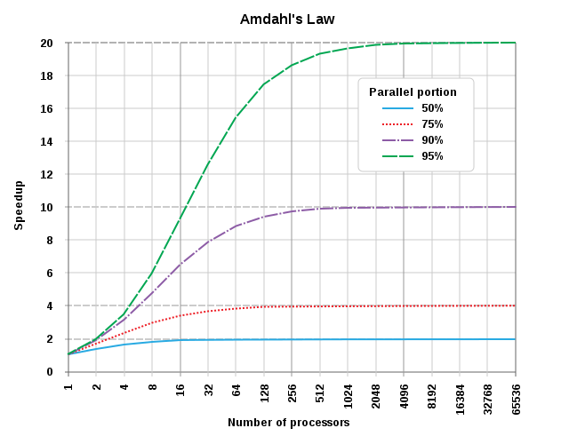

## MIMD

- Ovo je svet u kome mi, u stvari, živimo
- No, ponekad, to se krije od nas
- Najčistiji primer ovako nečega jeste sistem čvorova, gde je svaki čvor procesor koji komunicira sa drugim čvorovima preko mreže
- Provešćemo najviše vremena u hibridnom MIMD/SIMD svetu

## Multiprocesori

- Praktično ovaploćenje MIMD pristupa.
- To je arhitektura modernih super-računara. Mnogo čvorova, mnogo procesora.
- Multiprocesorske arhitekture imaju varijacije

## Multiprocesori deljene memorije

- Sistem gde imamo $N$ procesora, deljenu magistralu, i jednu memoriju za sve.
- Idealno, ovo funkcioniše kao UMA arhitektura — uniform memory access. To znači da bilo koji deo memorije je ne samo jednako dostupan bilo kom procesoru, nego je dostupan u jednakom vremenu.

## Multiprocesori deljene memorije

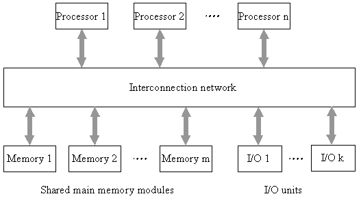

## Problem keša

- Koherentnost keša je ogroman problem za ovakve arhitekture
- Tipično se koristi Modified Exclusive Shared Invalid protokol, tkzv. MESI.
- Poznat još i kao ‘njuškalo keš’ (Snooping cache)
- UMA je moguća (donekle) na običnom računaru
- Ali današnje mašine su skoro sve NUMA, tj. ne UMA: neka memorija je blizu a neka daleko. Fizički a i logički.

## Masivno paralelni multiprocesori

- MPM-ovi nemaju deljenu memoriju nego distribuiranu memoriju.
- Striktno govoreći (i u stilu toga što su nam sve oznake labave i predstavljaju samo proizvoljne linije povučene po kontinualnim skalama) model distribuirane memorije je samo ekstreman NUMA model.
- Kako?
- Pa čvor ima svoju memoriju koja je NUMA-tično manje-više deljena, ali je povezan sa svim drugim čvorovima preko interfejsa za prosleđivanje poruka koji, tehnički, omogućava pristup (iako jako spor i indirektan) svoj memoriji sistema.

## Potrošački klasteri

- Potrošački klaster (comodity cluster) nije toliko posebna arhitektura koliko je specifična implementacija masivno paralelne arhitekture.
- Ideja je da se MPM arhitektura implementira upotrebljavajući hardver koji je namenjen potrošačima
- Zašto ovo radi?
  - Ekonomije skale.
  - Video igre.
- Naravno rešenje je manje efikasno: vrhunska MPM rešenja su skoro pa 90% efikasna na odabranim problemima.
- Čak i najbolji potrošački klasteri retko probijaju 60%.
- Ali su mnogo jeftiniji i ekonomski se skaliraju fantastično.

## Internet-bazirani potrošački klasteri

- Ekstreman primer ovoga jeste ideja da svako ko hoće može da postane deo super-računara koji rešava neki ogroman problem.
- Folding@home, na primer.
- O ovome pričamo na predmetu Računarstvo u Oblaku
- Ovo je slučaj gde je izolovanost čvorova komično velika, ali je to i dalje sasvim OK za određeni tip problema, uglavnom u kategoriji smešno paralelnih (više o tome kasnije).
- Najuspešniji primer je verovatno globalna bitcoin mreža
- 1.2 miliona miliona milijardi proračuna SHA256 vrednosti svakog sekunda.

## MISD

- Neki smatraju da je ovo besmislena kategorija
- Isti podaci a više tokova instrukcija?!
- Imaju dve klasične interpretacije:
  - Coarse-grained pipeline
  - Deljena memorija
- Na jedan način, moglo bi se reći da će OpenMP sa kojim se suočavate uskoro primer MISD arhitekture.

# Anatomija klastera u praksi

Šta je to što imamo?

## Commodity Cluster

- Dosta je priče o tome kako računari možda izgledaju i kako su nekad izgledali.
- Kako izgleda super-računar danas?
  - Ključnije: Kako izgleda super-računar koji *mi* koristimo.

## Arhitektura ugrubo

- Imamo više čvorova koji su povezani nekakvom mrežom.
- Svaki čvor ima:
  - $n$ fizičkih procesora koji imaju
  - $m$ logičkih procesora (jezgara) koji podržavaju
  - $k$ niti izvršavanja
  - neku količinu $l$ memorije koji ti procesori dele
  - $g$ kartica za ubrzanje sa svojim specijalizovanim resursima za proračunavanje
- Ti čvorovi su povezani u jedan sistem kroz nekakvu mrežu

## U praksi…

- Računari sa kojima mi radimo će gotovo sigurno biti commodity cluster tipa.
- To znači 1 čvor = 1 PC
- Taj neki čvor ima:
  - 1-2 procesora
  - 16-128 jezgara koji podržavaju po
  - 1-2 niti izvršavanja
  - Neki broj GB memorije (16GB-512GB)
  - Neki broj grafičkih kartice tipično NVidia tipa
- Svi čvorovi su povezani na brzu mrežu.

## Tipično NVidia?

- Ovaj predmet ne sponzoriše NVidia
- Razlog što su NVidia kartice tipične se vrti oko toga što, kada je u pitanju naučna primena GPU uređaja, NVidia je stigla prva.
- Kao rezultat toga što je to prvo počelo na NVidia karticama, dosta softvera je napravljeno sa tom idejom na umu
- Danas, polako, svi proizvođači kartica počinju da podržavaju naučni rad
- Najbrži računar, na primer, je baziran na potpuno custom procesorima dizajniranim u Kini; drugi i treći najbrži su AMD-bazirani.

## U praksi…

- Svaki računar je individualna mašina, sa svojom instalacijom Linux-a.
- Na svakom računaru su instalirani određeni alati, biblioteke, itd. koje omogućavaju da se resursi između računara efektno iskoriste.
- Primer:
  - OpenMP nam omogućava da koristimo paralelizam na nivou te jedne mašine.
  - OpenMPI nam omogućava da koristimo paralelizam između mašina.
  - OpenACC nam omogućava da koristimo GPU resurse na udoban način.
    - Alternative su CUDA, ROCm, OpenCL…
  - SLURM nam omogućava da kontrolišemo šta se izvršava i gde.

## Naš plan

- Da bi savladali ovo, naš plan jeste da:
  - **Benchmarking.** Naučimo kako merimo i biramo super-računarsku instalaciju.
  - **Resource** management. Naučimo kako da upravljamo onim što imamo.
  - **Parallel programming.** Naučimo tehnologije koje nam omogućavaju paralelizme.
  - **The Problem.** Savladamo neke primere problema sa kojima se suočavamo i smislimo kako da ih ubrzamo.
  - **Domain specific libraries.** Naučimo kako da koristimo specijalizovane biblioteke za istu svrhu.
  - **Visualization.** Naučimo kako da prikažemo šta smo izračunali.

# Merenje performansi HPC sistema

Koliko je brzo ‘brzo’

## Koncept

- Sabiranje performansi konstituenata HPC sistema proizvodi nekakve brojeve: toliko-i-toliko FLOPS-a.
- To nisu osobito korisni brojevi. Mogli bi i da sabiramo težine komponenti: koja je svrha ako nam ta vrednost nešto ne kaže.
- Možemo da modeliramo ponašanje, ali taj model bi uskoro postao izuzetno nezgodan za korišćenje i opet ne bi uhvatio sve detalje ponašanja.
- Rešenje je jednostavno: postavimo nekakav problem i merimo koliko je naš sistem dobar u njegovom rešavanju.
- Ako razmislite o tome, ovo je isto što se radi studentima:
  - Postavi se problem (ispit)
  - I mere se performanse (ocena).

## Problemi

- Naravno, ni ovo nije savršeno.
- Kakav tip problema se izabere, kako se postavi, konfiguriše, i koristi jako utiče na rezultat koji se dobije.
- Grubo gledajući, možemo da podelimo sva merenja performansi na:
  - Sintetičke
  - Prirodne
- Sintetički se lako kontrolišu i skaliraju.
- Prirodni daju izuzetno verodostojne rezultate—samo što nismo sigurni šta je to što mere.
- Primer van HPC: 3DMark vs. framerate.

## Malo istorije…

- Prvi benchmark ikada je bio za ENIAC (prikladno) i bio je računanje trajektorije đuleta u odnosu na isti proračun koji obavlja balistički računar ili ljudsko biće.
- Inženjer je, na kraju krajeva, prvobitno bio vojni termin.
- Prvi benchmark u široj upotrebi je ‘Whetstone’ nazvana po gradiću u kome je razvijena.
- Whetstone benchmark je bila kolekcija programa koji su stvarali sintetički problem koji je evaluirao broj instrukcija u datoj sekundi. Kasnije, kako su se potrebe menjale, počeo je da uključuje i floating-point instrukcije, te je merio i FLOPS.

## Malo istorije…

- Pošto je Whetstone specijalizovan za FLOPS, napravljen mu je pandan koji meri performanse sa celim brojevima.
- A pošto programeri vole malo šta više od igre rečima, ovaj pandan se zvao ‘Dhrystone.’
- Danas Dhrystone je zamenjen sa SPECint paketom.
- I Whetstone i Dhrystone nisu bili namenjeni za HPC, već za evaluaciju procesora.

## Linpack

- Najuticajniji benchmark u upotrebi se pojavio 1979 i baziran je na bibliotekama za linearnu algebru poznate kao Linpack (danas zamenjene sa Lapack/BLAS paketom softvera).
- Linpack meri performanse floating-point operacija, i baziran je na rešenju problma oblika:

## Linpack

$$Ax = B$$

Gde je $A$ $n \times n$ matrica, $x$ je vektor $x_0, x_1, \ldots x_{n-1}$, $b$ je vektor $b_0, b_1, \ldots b_{n-1}$ **Ograničenje:** A mora da ima malo ili nimalo elemenata koji su jednaki ili blizu nule, još se kaže i $A$ je *gusta* matrica. Ovo je efektivno zadatak rešavanja sistema od $n$ jednačina sa $n$ nepoznatih.

## Linpack

- Linpack je prošao kroz iteracije:
  - Prva iteracija je stavljala n na 100 i algoritam koji je koristila je bio serijski. Da bi rezultat bio merodavan, izvorni kod nije smeo da bude modifikovan: jedino parametri kompajliranja.
  - Druga iteracija je podigla n na 1000 i:
    - Dozvolila je da se prilagođava izvorni kod faktorizatora i rešavača.
    - Dozvolila je, konsekventno, paralelizaciju.
    - Uvela je uslov tačnosti nad rezultatima.
- Treća iteracija je HPL.

## Highly Parallel Linpack

- Highly Parallel Linpack — HPL je naznačajniji benchmark svoje vrste. On, pre svega, se koristi da meri FLOPS vrednosti za super-računare i služi da se lista 500 najbržih odredi.
- HPL je uveo još značajnije promene:
  - Samo je problem fiksan
  - Veličina ulaznih podataka može da varira.
  - Softver može da varira
- Ove promene dozvoljavaju HPLu da se izvršava na uređajima sa distribuiranom memorijom.

## Parametri HPL-a

- Do 20 različitih zadataka je dozvoljeno, mi specificiramo koliko hoćemo da probamo.
- Svaki od zadataka je specificiran preko ‘n,’ tj. broja jednačina i broja nepoznatih.
- Zatim je dozvoljeno do 20 različitih veličina bloka
  - Bloka? Način na koji algoritmi ovog tipa rade jeste da rekurzivno razbijaju matricu na pod-matrice. Blok definiše koliki će biti individualni segment.
  - Gotovo sigurno je u rasponu 32..256 a određuje se empirijski.
- Zatim se specificira kako se matrica deli po čvorovima
- Dalje, kaže se koliko različitih konfiguracija procesnih čvorova se koristi za proračun.

## Malo više o blokovima

- Neka je naš zadatak da odredimo $C = AB$ gde su A, B, i C $8 \times 8$ matrice.
- Onda možemo da izdelimo sve te matrice u 4 $4 \times 4$ podmatrice.
  $$\begin{bmatrix}
  C_{11} & C_{12} \\
  C_{21} & C_{22}
  \end{bmatrix}
  =
  \begin{bmatrix}
  A_{11} & A_{12} \\
  A_{21} & A_{22}
  \end{bmatrix}
  \begin{bmatrix}
  B_{11} & B_{12} \\
  B_{21} & B_{22}
  \end{bmatrix}$$

## Malo više o blokovima

Gde je, npr:
$$A_{i,j} = \begin{bmatrix}
a_{i,j} & a_{i,j+1} \\
a_{i+1,j} & a_{i+1,j+1}
\end{bmatrix}$$

## Malo više o blokovima

A mi računamo:
$$C_{11} = A_{11}B_{11} + A_{12}B_{21}$$
$$C_{12} = A_{11}B_{12} + A_{12}B_{22}$$
$$C_{21} = A_{21}B_{11} + A_{22}B_{21}$$
$$C_{22} = A_{21}B_{12} + A_{22}B_{22}$$

## Malo više o blokovima

- Onda su ove pod-matrice su naši blokovi
- Naravno, umesto $4 \times 4$ to su, recimo, $256 \times 256$
- U praksi, ovo je ideal: nisu sve matrice.
- Veličine i distribucije ovih blokova se stalno menjaju i podešavaju
- Ideja je da se promoviše u kodu osobina *lokalnosti*
- Setite se situacije sa kešom

## Parametri HPL-a

- Zatim se specificiraju sve konfiguracije, jedna po jedna, u obliku $P \times Q$
- Zašto tako? Zato što se matrica bukvalno deli među čvorovima tako što se čvorovi zamisle u matričnoj organizaciji, te se svakom čvoru “odseče” određeni segment matrice.
- Ovo znači da će naš proces biti pokrenut, nužno, na $P \times Q$ čvorova, šta god drugo mi specificirali prilikom pokretanja.
- $P$ i $Q$ se biraju empirijki i zavise od topoloigije naše mreže. Ako je mreža u mesh topologiji tako da imamo više linija za svaki računar onda je najbolje da je $P$ blizu $Q$ a $Q$ malo veće od $P$. U slučaju prostog Ethernet-a najbolje je biti pljosnat: Za klaster od 4 računara, recimo, $1 \times 4$

## Parametri HPL-a

- Definiše se još i stepen tačnosti do kog računamo. `16.0` je tipična vrednost, mada se ona može povećavati i do stotina hiljada. Ovo je zbog nepreciznosti poređenja floating point brojeva, prvo, i skale koja se koristi za test.
- Ostatak služi za podešavanje algoritma o čemu više kada budemo radili linearnu algebru u HPC okruženju.

## Rezultati HPL-a

- HPL nam omogućava da odredimo veći broj vrednosti i od njih nas zanima:
  - `Rpeak` — Broj FLOPSa koji smo izračunali da je teoretski moguć
  - `Rmax + Nmax` — Ovo je veličina ulaznog skupa (`Nmax`) za koju je ostvaren najveći stvarni broj FLOPSa (`Rmax`).
  - `N1/2` — Veličina ulaznog skupa za koju je ostvareno pola maksimalne ostvarene performanse.

## Osobine dobrog benchmark sistema

- Da li je HPL dobar benchmark? Šta znači biti “dobar” u ovom kontekstu?
- Bazirano na iskustvu može se reći da dobar benchmark ima sledeće osobine:
  - **Realizam.** Mora simulirati tip rada na koji se nailazi u praksi.
  - **Univerzalnost.** Adekvatno radi na velikom broju arhitektura.
  - **Popularnost.** Dosta korisnika znači da imamo dosta uporedivih rezultata.
  - **Kompaktnost.** Mali broj linija koda znači manje šuma.
  - **Uređenost.** Postoje jasna pravila oko toga kako se dobijaju merodavni rezultati.
  - **Standardizovanost.** Upotreba standardnih tehnologija.

## HPC Challenge

- HPC Challenge Benchmark Suite je malo opširnija alternativa HPL sistemu.
- Sa pozitivne strane: meri mnogo više stvari.
- Sa negativne strane: ne proizvodi jednu stvar, nego više, što čini samerljivost kompleksnijom. Čak i da primenimo matematičku koncepciju razdaljine u višedimenzionalnom prostoru, i dalje moramo da ustanovimo zajedničku skalu plus da odredimo funkciju metrike. Kao rezultat moguće je formulisati beskonačno mnogo samerljivosti što nas ostavlja sa ogromnim koordinacionim problemom.

## HPC Challenge

- HPCC se sastoji od sledećih mera:
  - `DGEMM`
    - Množenje matrica * matrica, slično HPL u nameni
  - `STREAM`
    - Sintetički problem koji meri dugoročnu protočnu moć memorije
  - `PTRANS`
    - Paralelizovano transponovanje matrica

## HPC Challenge

- HPCC se sastoji od sledećih mera:
  - `RandomAccess`
    - Nasumično postavlja nove celobrojne vrednosti u nasumične delove memorije. Meri se u Giga Updates Per Second: GUPS.
  - `FFT`
    - Jednodimenzionalna kompleksna diskretizovana Furjeova transformacija
  - `B_eff`
    - Kašnjenje i protočna moć za različite obrasce komunikacije

## Šta odlikuje HPCC?

- Fokus na memoriju.
- Distribuirani sistemi su izuzetno osetljivi na zadatke koji zahtevaju slobodan tok podataka kroz ceo sistem.
- HPCC stress-testira baš ovaj deo koji konvencionalniji HPL uglavnom ignoriše.
- Ovo ne čini HPL-lošim niti HPCC dobrim.
  - Što?
  - **Namena računara diktira šta želimo da merimo.**

## High Performance Conjugate Gradients

- HPCG održavaju isti ljudi kao i HPL i služi da meri stvari koje HPL ne dodiruje.
- Problem koji HPC rešava je sasvim isti kao onaj koji rešava HPL
- Pa koja je onda razlika?

## HPCG

Rešavamo problem:
$$Ax = B$$
Gde je $A$ $n \times n$ matrica, $x$ je vektor $x_0, x_1, \ldots x_{n-1}$, $b$ je vektor $b_0, b_1, \ldots b_{n-1}$ **Ograničenje:** Ali sada $A$ ima **većinu** elemenata koji su 0 ili vrlo blizu nula, odnosno A je *retka* matrica.

## NAS Parallel Benchmarks

- NPB je sličan HPCC sistemu u tome što predstavlja kombinaciju tipičnih problema.
- Specifično predstavlja 8 tipičnih problema koji su poznati pod svojim dvoslovnim skraćenicama.

## NPB

- **IS** (Integer Sort) - Sortiranje celih brojeva. Testira celobrojnu brzinu i performanse mreže.
- **EP** (Embarassingly parallel) - Testira brzine blizu teoretskog maksimuma.
- **CG** (Conjugate Gradient) - Radi račun karakteristične vrednosti retke matrice.
- **MG** (MultiGrid) - Integracija diferencijalne jednačine kroz metodu više rezolucija.

## NPB

- **FT** (Discrete 3D FFT) - Integracija parcijalne diferencijalne jednačine kroz brze Furijeove transformacije
- **BT** (Block Tridiagonal Solver) - Rešavanje sistema jednačina trodijagonalnog tipa.
- **SP** (Scalar Pentadiagonal Solver) - Rešavanje sistema jednačina pentadijagonalnog tipa.
- **LU** (LU Gauss-Seidel solver) - Isto što i HPL efektivno

## Pentadijagonalno? Tridijagonalno?

- HPC *mnogo* voli matrice te je korisno da znate terminologiju
- *Retka* matrica je takva da joj je većina elemenata nula.
- *Trakasta* matrica je retka matrica takva da su joj nenulti elementi isključivo na glavnoj dijagonali i na nekim dijagonalama iznad glavne i ispod glavne, ili formalno govoreći:

$a_{i,j}=0$ ako $j<i-k_1$ ili $j>i+k_2$ za $k_1, k_2 \ge 0$

## Trakaste matrice

- Vrednosti $k_1$ i $k_2$ su gornja i donja *širina trake*
- Ako $k_1 = k_2$ onda je ovo simetrična trakasta matrica, i obično se zove $n$-dijagonalna, po tome koliko ukupno dijagonala ima popunjenih ili delimično popunjenih.
- Stoga:
  - Ako je $k_1 = k_2 = 1$ onda je tridijagonalna matrica u pitanju
  - Ako je $k_1 = k_2 = 2$ onda je pentadijagonalna matrica u pitanju
  - Ako je $k_1 = k_2 = 3$ onda je heptadijagonalna matrica u pitanju
  - …

## Graph 500

- Do ovog trenutka, postoji određena tendencija u svim ovim merama:
  - Diferencijalne jednačine.
  - Sistemi linearnih jednačina raznih tipova.
  - Bazične celobrojne operacije.
- Ovo su primeri problema simulacija za građevinu, mašinstvo, i fiziku, opšte govoreći.
- To je lepo, ali nisu svi problemi ovakvi.
- Veliki skupovi problema se predstavljaju kroz operacije nad grafovima.

## Graph500

- Graph500 ne samo da odgovara tom domenu nego radi i u širem kontekstu—simulira aplikacije sa intenzivnim pristupom podacima.
- Graph500 definiše, u stvari, 3 benchmark-a
  - Graph500 1 — konkurentna pretraga
  - Graph500 2 — Najkraća putanja
  - Graph500 3 — Najveći nezavisni skup (tj. najveći skup čvorova grafa takvih da nikoja dva nisu povezana)
- Samo Graph500 1 je implementiran i to preko Breadth First Search pristupa, tako što za 64 jedinstvena početna čvora u tom grafu nađe sve čvorove do kojih se može doći.
- Graf je cikličan, bez težina, i neusmeren.

## Graph500

- Graph500 je implementiran sa istovremenim OpenMP i OpenMPI paralelizmom što odgovara modernim sistemima.
- Rezultate ne vraća u FLOPS nego u TEPS (Traversed Edges Per Second)
- Poređenje između FLOPS i TEPS je teško ali ima jedna druga stvar koja je *jako bitna:*
  - U FLOPS-ima računari nastavljaju svoj eksponencijalni rast.
  - U TEPS-ima performanse stagniraju.
  - Arhitekture deljene memorije su mnogo bolje (u kontekstu TEPS po jezgru) od arhitektura distribuirane memorije.
  - Ovo možete čitati kao “breakthrough wanted” znak.

## Miniaplikacije

- Sve do sada, svi ovi benchmark-ovi rade sa sintentičkim podacima koji pokušavaju da simuliraju šta bi stvarna aplikativna primena postigla.
- Mogu se meriti rezultati punih aplikacija, naravno, ali su oni tako specifični da nisu osobito korisni: nisu univerzalni i nisu sveprisutni.
- Pokušaj da se odradi kvadratura kruga ovde jesu miniaplikacije: pojednostavljeni ali realni poslovi.
- Ovoga se dotičemo kada budemo radili domenski-specifične biblioteke mnogo, mnogo kasnije.